# Mouse Pregnancy Plasma Exosome Time Course - Day 1

Sean Nguyen

# Experimental Design

Six animals will be use for six different time points throughout pregnancy

# Importing your data

This section will demonstrate how to get started with analyzing data using R.

**You will first want to tell R where to find all of your files, you can do this with the “setwd” command**  
- This is where R will read in all of your files and output your data that you generate(plots, CSVs, etc)

**You can abbreviate long filenames by calling it an object, in this case we can make our long csv = “my data”**  
- This way you can just use “mydata” and it will automatically insert the filename

**Next we will want to import the csv into r and we can accomplish this with the “read_csv” function**  
- This will import our csv file and we can make this an object known as “data”  
- Anytime we want to see the dataframe we can simply run “data”

```r
setwd("~/NanoVideos/2017-02-13/")
```

[output not shown]

```r
mydata <- "sample_combined-ExperimentSummary.csv"
data <- read_csv(mydata)
```

We can quickly look at the dimensions of the dataframe with **dim()**

```r
dim(data)
```

```
[1] 1000   37
```

We can see the top of the dataframe with **head()**

| particle_size | 23_500_2_00 | 23_500_2_01 | 23_500_2_02 | 23_500_1_00 | 23_500_1_01 | 23_500_1_02 | 12_500_2_00 | 12_500_2_01 | 12_500_2_02 | 12_500_1_00 | 12_500_1_01 | 12_500_1_02 | 3_500_2_00 | 3_500_2_01 | 3_500_2_02 | 3_500_1_00 | 3_500_1_01 | 3_500_1_02 | 1_500_2_00 | 1_500_2_01 | 1_500_2_02 | 1_500_1_00 | 1_500_1_01 | 1_500_1_02 |
| --- | --- | --- | --- | --- | --- | --- | --- | --- | --- | --- | --- | --- | --- | --- | --- | --- | --- | --- | --- | --- | --- | --- | --- | --- |
| 0.5 | 0 | 0 | 0 | 0 | 0 | 0 | 0 | 0 | 0 | 0 | 0 | 0 | 0 | 0 | 0 | 0 | 0 | 0 | 0 | 0 | 0 | 0 | 0 | 0 |
| 1.5 | 0 | 0 | 0 | 0 | 0 | 0 | 0 | 0 | 0 | 0 | 0 | 0 | 0 | 0 | 0 | 0 | 0 | 0 | 0 | 0 | 0 | 0 | 0 | 0 |
| 2.5 | 0 | 0 | 0 | 0 | 0 | 0 | 0 | 0 | 0 | 0 | 0 | 0 | 0 | 0 | 0 | 0 | 0 | 0 | 0 | 0 | 0 | 0 | 0 | 0 |
| 3.5 | 0 | 0 | 0 | 0 | 0 | 0 | 0 | 0 | 0 | 0 | 0 | 0 | 0 | 0 | 0 | 0 | 0 | 0 | 0 | 0 | 0 | 0 | 0 | 0 |
| 4.5 | 0 | 0 | 0 | 0 | 0 | 0 | 0 | 0 | 0 | 0 | 0 | 0 | 0 | 0 | 0 | 0 | 0 | 0 | 0 | 0 | 0 | 0 | 0 | 0 |
| 5.5 | 0 | 0 | 0 | 0 | 0 | 0 | 0 | 0 | 0 | 0 | 0 | 0 | 0 | 0 | 0 | 0 | 0 | 0 | 0 | 0 | 0 | 0 | 0 | 0 |

You can also look at the bottom with **tail()**

```r
tail(data)
```

[output not shown]

# Convert data from wide type to long

| particle_size | Sample | Count |
| --- | --- | --- |
| 0.5 | 23_500_2_00 | 0 |
| 1.5 | 23_500_2_00 | 0 |
| 2.5 | 23_500_2_00 | 0 |
| 3.5 | 23_500_2_00 | 0 |
| 4.5 | 23_500_2_00 | 0 |
| 5.5 | 23_500_2_00 | 0 |
| 6.5 | 23_500_2_00 | 0 |
| 7.5 | 23_500_2_00 | 0 |
| 8.5 | 23_500_2_00 | 0 |
| 9.5 | 23_500_2_00 | 0 |

[output cut: 990 more lines]

# Separate samples by identifiers

```r
data2 <- data1 %>%
  separate(Sample, into=c("Sample_ID","Dilution_factor","Injection","Tech_rep", sep = "_")) %>%
  select(-`_`)
```

```
Too few values at 36000 locations: 1, 2, 3, 4, 5, 6, 7, 8, 9, 10, 11, 12, 13, 14, 15, 16, 17, 18, 19, 20, ...
```

```r
data2
```

|  | particle_size | Sample_ID | Dilution_factor | Injection | Tech_rep | Count |
| --- | --- | --- | --- | --- | --- | --- |
| 1 | 0.5 | 23 | 500 | 2 | 00 | 0 |
| 2 | 1.5 | 23 | 500 | 2 | 00 | 0 |
| 3 | 2.5 | 23 | 500 | 2 | 00 | 0 |
| 4 | 3.5 | 23 | 500 | 2 | 00 | 0 |
| 5 | 4.5 | 23 | 500 | 2 | 00 | 0 |
| 6 | 5.5 | 23 | 500 | 2 | 00 | 0 |
| 7 | 6.5 | 23 | 500 | 2 | 00 | 0 |
| 8 | 7.5 | 23 | 500 | 2 | 00 | 0 |
| 9 | 8.5 | 23 | 500 | 2 | 00 | 0 |
| 10 | 9.5 | 23 | 500 | 2 | 00 | 0 |

[output cut: 990 more lines]

# Data types

R works with a variety of different data structures including, strings, vectors, factors, lists, integers, numerics and characters.  
What I found that works for me is to think of factors and categorical variables.

We can inspect the structure of the data type

```r
str(data2)
```

```
Classes ‘tbl_df’, ‘tbl’ and 'data.frame':   36000 obs. of  6 variables:
 $ particle_size  : num  0.5 1.5 2.5 3.5 4.5 5.5 6.5 7.5 8.5 9.5 ...
 $ Sample_ID      : chr  "23" "23" "23" "23" ...
 $ Dilution_factor: chr  "500" "500" "500" "500" ...
 $ Injection      : chr  "2" "2" "2" "2" ...
 $ Tech_rep       : chr  "00" "00" "00" "00" ...
 $ Count          : int  0 0 0 0 0 0 0 0 0 0 ...
```

# Fixing data types

We can fix the data types to make things a factor (typically categorical variables) or numeric for numbers The typical way to reformat data types is to call the data and specify the column name using **dataframe_name$column_name**  
Next you need to assign the column name **as.factor()** or **as.numeric()**, be sure to make sure the column is specified  
Then you will want to make **as.factor()** or **as.numeric()** equal to the column that you are changing

Afterwards, be sure to check the data structure to make sure you did things correctly using the **str()**

```r
str(data2)
```

```
Classes ‘tbl_df’, ‘tbl’ and 'data.frame':   36000 obs. of  6 variables:
 $ particle_size  : num  0.5 1.5 2.5 3.5 4.5 5.5 6.5 7.5 8.5 9.5 ...
 $ Sample_ID      : Factor w/ 6 levels "1","12","14",..: 4 4 4 4 4 4 4 4 4 4 ...
 $ Dilution_factor: num  500 500 500 500 500 500 500 500 500 500 ...
 $ Injection      : Factor w/ 2 levels "1","2": 2 2 2 2 2 2 2 2 2 2 ...
 $ Tech_rep       : num  0 0 0 0 0 0 0 0 0 0 ...
 $ Count          : int  0 0 0 0 0 0 0 0 0 0 ...
```

# Back-Calculate

| particle_size | Sample_ID | Dilution_factor | Injection | Tech_rep | Count | True_Count |
| --- | --- | --- | --- | --- | --- | --- |
| 0.5 | 23 | 500 | 2 | 0 | 0 | 0 |
| 1.5 | 23 | 500 | 2 | 0 | 0 | 0 |
| 2.5 | 23 | 500 | 2 | 0 | 0 | 0 |
| 3.5 | 23 | 500 | 2 | 0 | 0 | 0 |
| 4.5 | 23 | 500 | 2 | 0 | 0 | 0 |
| 5.5 | 23 | 500 | 2 | 0 | 0 | 0 |
| 6.5 | 23 | 500 | 2 | 0 | 0 | 0 |
| 7.5 | 23 | 500 | 2 | 0 | 0 | 0 |
| 8.5 | 23 | 500 | 2 | 0 | 0 | 0 |
| 9.5 | 23 | 500 | 2 | 0 | 0 | 0 |

[output cut: 990 more lines]

We can use **group_by()** to effectively ‘lock’ in certain variables/factors within a particular column. In our case we will use group_by to ‘lock’ the particle_size, dilution factor and injection columns.  
**mutate()**is a command that will create a new column, the name of the column comes first and then whatever you want the column to be comes afterwards. Example code `data %>% mutate(new_column_name=column1*column2)`  
Next we can use **summarise()** to calculate the number of rows within a certain group, calculate the average, standard deviation and standard error of the mean.

| particle_size | Sample_ID | Dilution_factor | Injection | tech_N | tech_mean | tech_sd | tech_se |
| --- | --- | --- | --- | --- | --- | --- | --- |
| 0.5 | 1 | 500 | 1 | 3 | 0.000000e+00 | 0.000000e+00 | 0.000000e+00 |
| 0.5 | 1 | 500 | 2 | 3 | 0.000000e+00 | 0.000000e+00 | 0.000000e+00 |
| 0.5 | 12 | 500 | 1 | 3 | 0.000000e+00 | 0.000000e+00 | 0.000000e+00 |
| 0.5 | 12 | 500 | 2 | 3 | 0.000000e+00 | 0.000000e+00 | 0.000000e+00 |
| 0.5 | 14 | 500 | 1 | 3 | 0.000000e+00 | 0.000000e+00 | 0.000000e+00 |
| 0.5 | 14 | 500 | 2 | 3 | 0.000000e+00 | 0.000000e+00 | 0.000000e+00 |
| 0.5 | 23 | 500 | 1 | 3 | 0.000000e+00 | 0.000000e+00 | 0.000000e+00 |
| 0.5 | 23 | 500 | 2 | 3 | 0.000000e+00 | 0.000000e+00 | 0.000000e+00 |
| 0.5 | 3 | 500 | 1 | 3 | 0.000000e+00 | 0.000000e+00 | 0.000000e+00 |
| 0.5 | 3 | 500 | 2 | 3 | 0.000000e+00 | 0.000000e+00 | 0.000000e+00 |

[output cut: 990 more lines]

# Refactoring to get the sample ID in the correct order

We can explicitly change the order of levels in a factor by telling R to do so.  
In order to do this, you have to specify what dataframe you want, in our case we will specify “data3” and the “Sample_ID” column. In R, we designate columns with `$`. The general formula is `dataframe$column <- factor(dataframe$column, levels=c("First","Second","Third","Last"))`

# Summarize samples by injection

| particle_size | Sample_ID | Dilution_factor | inj_N | inj_mean | inj_sd | inj_se |
| --- | --- | --- | --- | --- | --- | --- |
| 0.5 | 1 | 500 | 2 | 0.000000e+00 | 0.000000e+00 | 0.000000e+00 |
| 0.5 | 3 | 500 | 2 | 0.000000e+00 | 0.000000e+00 | 0.000000e+00 |
| 0.5 | 12 | 500 | 2 | 0.000000e+00 | 0.000000e+00 | 0.000000e+00 |
| 0.5 | 14 | 500 | 2 | 0.000000e+00 | 0.000000e+00 | 0.000000e+00 |
| 0.5 | 23 | 500 | 2 | 0.000000e+00 | 0.000000e+00 | 0.000000e+00 |
| 0.5 | 30 | 800 | 2 | 0.000000e+00 | 0.000000e+00 | 0.000000e+00 |
| 1.5 | 1 | 500 | 2 | 0.000000e+00 | 0.000000e+00 | 0.000000e+00 |
| 1.5 | 3 | 500 | 2 | 0.000000e+00 | 0.000000e+00 | 0.000000e+00 |
| 1.5 | 12 | 500 | 2 | 0.000000e+00 | 0.000000e+00 | 0.000000e+00 |
| 1.5 | 14 | 500 | 2 | 0.000000e+00 | 0.000000e+00 | 0.000000e+00 |

[output cut: 990 more lines]

# Graphing data

Now that the data is structured properly we can graph the data to get an idea of what is going on.  
We will use the **ggplot()**

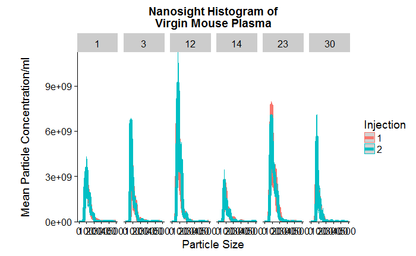

Next we can graph **data4**

[figure not shown]

Next we can create a publication Quality figure by combining both graph1 and graph2 using the **plot_grid()** function from the cowplot library.

```r
plot_grid(graph1,graph2, labels = c("Individual\nInjections","Averaged"),nrow = 2, align = "v")
```

[output not shown]